# Supplementary materials | Investigating Glottal Stop Coda Loss During Sound Change of Checked Syllables Based on Speech-EGG Voice Offset Alignment

Bingliang Zhao

2025-05-30

# Get ready

Data from four female participants (OF8, OF9, YF6, YF7) and one male participant (OM6) were excluded due to the poor quality of their EGG signals.

Audio files with incidental noise were also excluded.

```r
# load the original database
load('ZhaoInterspeech2025.RData')

# Marking the outliers for every age*sex group using the 3-standard deviation criterion
df.ALL = df.interspeech2025data %>%
  group_by(age,sex) %>%
  mutate(VOL_mean = mean(VOL,na.rm = TRUE),
         VOL_sd = sd(VOL,na.rm = TRUE),) %>%
  ungroup()
df.ALL$outlier = ifelse(df.ALL$VOL >= df.ALL$VOL_mean-3*df.ALL$VOL_sd & df.ALL$VOL <= df.ALL$VOL_mean+3*df.ALL$VOL_sd,0,1)

# 3,027 valid tokens for subsequent analysis
df.VALID = filter(df.ALL,outlier == 0)
```

Calculate R<sup>2</sup> of CQ & VOL for every participant.

```r
participants = unique(df.ALL$participant)
paras = c('CQ', 'VOL')
df.R2 = data.frame(participants)
colnames(df.R2)[1] = 'participant'
colnames(df.participantInfo)[1] = 'participant'
df.R2$age = ifelse(substr(as.character(df.R2$participant),1,1) == "O", 'Old','Young')
df.R2$sex = ifelse(substr(as.character(df.R2$participant),2,2) == "M", 'Male','Female')
df.R2 = merge(df.R2,df.participantInfo,by = 'participant')
```

Run GLMs for every participant

```r
for (i in c(1:length(participants))){
  for (para in paras){
    m = lm(get(para) ~ syllable_type,data = filter(df.ALL,participant == participants[i]))
    # dependent variable: CQ / VOL
    # fixed factor: syllable type (binary coded)
    summary_model = summary(m)
    p_value = summary_model$coefficients[2, 4]
    beta = summary_model$coefficients[2, 1]
    r2_adj = summary_model$adj.r.squared
    df.R2[i,paste(para,'p',sep='_')] = p_value
    df.R2[i,paste(para,'b',sep='_')] = beta
    df.R2[i,paste(para,'r',sep='_')] = r2_adj
    if (para == 'VOL'){
      df.R2[i,paste(para,'Yes',sep='_')] = ifelse(p_value < 0.05 & beta<0,1,0)
    }
    else{
      df.R2[i,paste(para,'Yes',sep='_')] = ifelse(p_value < 0.05 & beta>0,1,0)
    }
  }
}
```

As checked syllables are expected to have more glottal constriction, higher CQ is anticipated for checked. Therefore, CQ_Yes is a binary factor whose value is equal to 1 when checked CQ is significantly higher than unchecked CQ (beta > 0 & p < .05).

VOL_Yes is a binary factor whose value is equal to 1 when checked VOL is significantly lower than unchecked CQ (beta < 0 & p < .05).

```r
df.R2$CQ_Yes = factor(df.R2$CQ_Yes)
df.R2$VOL_Yes = factor(df.R2$VOL_Yes)
```

# Statistical analysis

## Section 3.1

The R<sup>2</sup>s, beta coefficients, and *p* values of CQ/VOL generated from GLMs for every participant can be seen in **df.R2** (visualized in the following figure).

| participant | age | sex | YearOfBirth | CQ_p | CQ_b | CQ_r | CQ_Yes | VOL_p | VOL_b | VOL_r | VOL_Yes |
| --- | --- | --- | --- | --- | --- | --- | --- | --- | --- | --- | --- |
| OF1 | Old | Female | 1962 | 0.5413376 | 0.7536608 | -0.0069822 | 0 | 0.0011721 | -15.2778195 | 0.1022333 | 1 |
| OF2 | Old | Female | 1961 | 0.0010334 | 3.3002786 | 0.1034852 | 1 | 0.0000294 | -20.1146377 | 0.1680153 | 1 |
| OF3 | Old | Female | 1969 | 0.0076267 | 3.1574325 | 0.0654881 | 1 | 0.0206051 | -12.5489674 | 0.0471461 | 1 |
| OF4 | Old | Female | 1972 | 0.3298793 | 0.8760920 | -0.0004356 | 0 | 0.0545442 | -3.5162738 | 0.0291476 | 0 |
| OF5 | Old | Female | 1973 | 0.0008221 | -3.5682650 | 0.1100455 | 0 | 0.0027756 | -17.3846139 | 0.0869571 | 1 |
| OF6 | Old | Female | 1964 | 0.1114367 | 1.2159970 | 0.0175015 | 0 | 0.0000007 | -20.5512914 | 0.2357190 | 1 |
| OF7 | Old | Female | 1977 | 0.0454980 | -2.9374405 | 0.0367268 | 0 | 0.2520818 | 2.9379710 | 0.0040161 | 0 |
| OFA | Old | Female | 1966 | 0.0000008 | 7.2606804 | 0.2314296 | 1 | 0.0000549 | -22.8610323 | 0.1585786 | 1 |
| OM1 | Old | Male | 1965 | 0.0013571 | 4.6867077 | 0.0973934 | 1 | 0.1267165 | -2.6126087 | 0.0147317 | 0 |
| OM2 | Old | Male | 1958 | 0.0000000 | 10.4081271 | 0.4753744 | 1 | 0.0000000 | -43.6780147 | 0.4772370 | 1 |
| OM3 | Old | Male | 1969 | 0.0000001 | 6.2995999 | 0.2683136 | 1 | 0.0072433 | -9.6981138 | 0.0678946 | 1 |
| OM4 | Old | Male | 1968 | 0.0000001 | 7.0679765 | 0.2661813 | 1 | 0.0000011 | -21.7131884 | 0.2244030 | 1 |
| OM5 | Old | Male | 1969 | 0.0005194 | 4.5107890 | 0.1174267 | 1 | 0.5879782 | 0.7119565 | -0.0078878 | 0 |
| OM7 | Old | Male | 1968 | 0.0000000 | 6.6024791 | 0.3274120 | 1 | 0.0001014 | -13.0233452 | 0.1429951 | 1 |
| OM8 | Old | Male | 1963 | 0.0000000 | 12.5909997 | 0.7566805 | 1 | 0.0000000 | -32.6116304 | 0.3860492 | 1 |
| OM9 | Old | Male | 1970 | 0.0000134 | 4.6014612 | 0.1781820 | 1 | 0.3759501 | -2.1497024 | -0.0022464 | 0 |
| OMA | Old | Male | 1958 | 0.0003838 | -1.9861053 | 0.1230406 | 0 | 0.0081911 | -11.9657992 | 0.0655706 | 1 |
| OMB | Old | Male | 1972 | 0.0005751 | 5.0244349 | 0.1167728 | 1 | 0.0284116 | -4.4717521 | 0.0426522 | 1 |
| YF1 | Young | Female | 2000 | 0.2001604 | 1.2704547 | 0.0073438 | 0 | 0.1155245 | 12.1266432 | 0.0166737 | 0 |
| YF2 | Young | Female | 2000 | 0.0343463 | 1.5381354 | 0.0374030 | 1 | 0.8348951 | -0.4619167 | -0.0103897 | 0 |
| YF3 | Young | Female | 1995 | 0.3338168 | 1.0067749 | -0.0006310 | 0 | 0.0603165 | -8.4893962 | 0.0289367 | 0 |
| YF4 | Young | Female | 1994 | 0.0000000 | 7.2040933 | 0.3452364 | 1 | 0.0253578 | -6.9775490 | 0.0438168 | 1 |
| YF5 | Young | Female | 1993 | 0.7545690 | 0.2749172 | -0.0098978 | 0 | 0.0579735 | 5.7973913 | 0.0283767 | 0 |
| YF8 | Young | Female | 1998 | 0.0960085 | -1.7108546 | 0.0199310 | 0 | 0.0118107 | -12.1696100 | 0.0586601 | 1 |
| YF9 | Young | Female | 1989 | 0.0414859 | -1.3337942 | 0.0351532 | 0 | 0.1077439 | 10.8449934 | 0.0178955 | 0 |
| YM1 | Young | Male | 1999 | 0.3809836 | -0.7617309 | -0.0024513 | 0 | 0.3129464 | -6.3739814 | 0.0003215 | 0 |
| YM2 | Young | Male | 1995 | 0.1809822 | 1.6212756 | 0.0093252 | 0 | 0.5816935 | -3.1518182 | -0.0080433 | 0 |
| YM3 | Young | Male | 1996 | 0.0507961 | -3.1593631 | 0.0314279 | 0 | 0.4526638 | -4.6794714 | -0.0048124 | 0 |
| YM4 | Young | Male | 1995 | 0.0085130 | 2.2248827 | 0.0641404 | 1 | 0.1839228 | -5.7802696 | 0.0086399 | 0 |
| YM5 | Young | Male | 2005 | 0.0000000 | 14.7169481 | 0.4384451 | 1 | 0.0000002 | -15.2673732 | 0.2538616 | 1 |
| YM6 | Young | Male | 1999 | 0.2566557 | 0.9548188 | 0.0035247 | 0 | 0.9734689 | -0.2418478 | -0.0117515 | 0 |
| YM7 | Young | Male | 2003 | 0.0072083 | 3.3466112 | 0.0857907 | 1 | 0.8844670 | -0.9135849 | -0.0139776 | 0 |
| YM8 | Young | Male | 2000 | 0.0000001 | 5.1134171 | 0.2604255 | 1 | 0.0683303 | 5.2218333 | 0.0251790 | 0 |
| YM9 | Young | Male | 1995 | 0.4626497 | 0.5237356 | -0.0050349 | 0 | 0.0891277 | 6.9812500 | 0.0210163 | 0 |

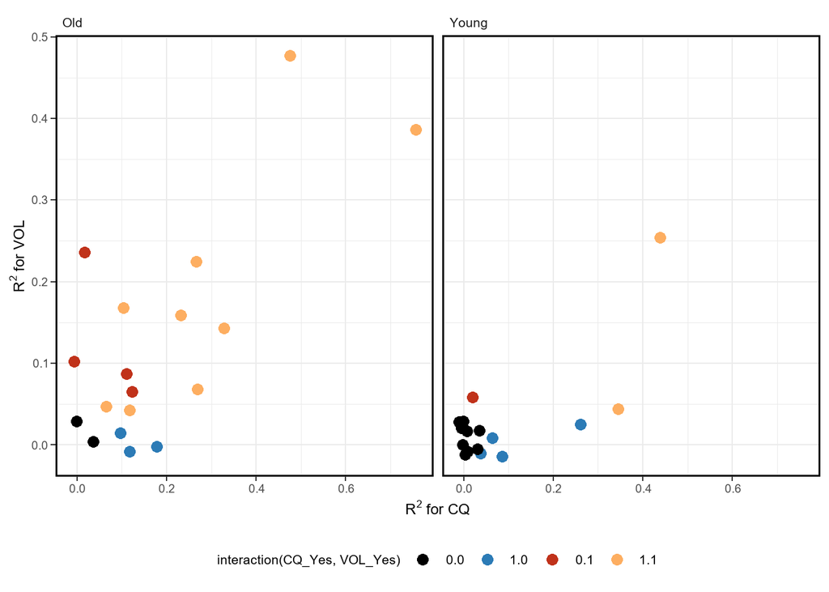

A strong positive correlation was discovered between R<sup>2</sup> values of VOL and CQ. All participants were included in the Pearson’s r test.

```r
cor.test(df.R2$CQ_r,df.R2$VOL_r)
```

```
##
##  Pearson's product-moment correlation
##
## data:  df.R2$CQ_r and df.R2$VOL_r
## t = 6.3088, df = 32, p-value = 4.453e-07
## alternative hypothesis: true correlation is not equal to 0
## 95 percent confidence interval:
##  0.5431013 0.8649277
## sample estimates:
##       cor
## 0.7445282
```

## Section 3.2

### Age-related differences in raw VOL

Linear mixed-effects models were employed to examine VOL differences between checked and unchecked syllables. Age & sex fixed effects and their interactions with syllable type were tested.

We first fitted the base model which included fixed effects of syllable_type/age/sex, their two-way/three-way interactions and random intercept of participant.

```r
m.base = lmer(VOL~syllable_type*age*sex + (1|participant), df.VALID)
```

Including random intercept of item significantly improved model fit compared to **m.base** (p < .05).

```r
m.itemAdd = lmer(VOL~syllable_type*age*sex + (1|participant) + (1|item), df.VALID)
anova(m.base,m.itemAdd)
```

```
## Data: df.VALID
## Models:
## m.base: VOL ~ syllable_type * age * sex + (1 | participant)
## m.itemAdd: VOL ~ syllable_type * age * sex + (1 | participant) + (1 | item)
##           npar   AIC   BIC logLik deviance  Chisq Df Pr(>Chisq)
## m.base      10 25177 25238 -12579    25157
## m.itemAdd   11 25120 25186 -12549    25098 59.576  1  1.177e-14 ***
## ---
## Signif. codes:  0 '***' 0.001 '**' 0.01 '*' 0.05 '.' 0.1 ' ' 1
```

Including random slope of syllable_type for participant significantly improved model fit compared to **m.itemAdd** (p < .05).

```r
m.typeAnditemAdd = lmer(VOL~syllable_type*age*sex + (syllable_type|participant) + (1|item), df.VALID)
anova(m.itemAdd, m.typeAnditemAdd)
```

```
## Data: df.VALID
## Models:
## m.itemAdd: VOL ~ syllable_type * age * sex + (1 | participant) + (1 | item)
## m.typeAnditemAdd: VOL ~ syllable_type * age * sex + (syllable_type | participant) + (1 | item)
##                  npar   AIC   BIC logLik deviance  Chisq Df Pr(>Chisq)
## m.itemAdd          11 25120 25186 -12549    25098
## m.typeAnditemAdd   13 24971 25049 -12473    24945 152.57  2  < 2.2e-16 ***
## ---
## Signif. codes:  0 '***' 0.001 '**' 0.01 '*' 0.05 '.' 0.1 ' ' 1
```

Including random slope of age/sex for item didn’t improve model fit compared to **m.itemAdd** (p > .05).

```r
m.itemAndageAdd = lmer(VOL~syllable_type*age*sex + (1|participant) + (age|item), df.VALID)
m.itemAndsexAdd = lmer(VOL~syllable_type*age*sex + (1|participant) + (sex|item), df.VALID)
anova(m.itemAdd, m.itemAndageAdd, m.itemAndsexAdd)
```

```
## Data: df.VALID
## Models:
## m.itemAdd: VOL ~ syllable_type * age * sex + (1 | participant) + (1 | item)
## m.itemAndageAdd: VOL ~ syllable_type * age * sex + (1 | participant) + (age | item)
## m.itemAndsexAdd: VOL ~ syllable_type * age * sex + (1 | participant) + (sex | item)
##                 npar   AIC   BIC logLik deviance Chisq Df Pr(>Chisq)
## m.itemAdd         11 25120 25186 -12549    25098
## m.itemAndageAdd   13 25118 25196 -12546    25092  5.96  2    0.05079 .
## m.itemAndsexAdd   13 25123 25201 -12548    25097  0.00  0
## ---
## Signif. codes:  0 '***' 0.001 '**' 0.01 '*' 0.05 '.' 0.1 ' ' 1
```

Including random slope of age&sex for item led to boundary (singular) fit or failure to converge.

```r
m.itemAndageAndsexAdd = lmer(VOL~syllable_type*age*sex + (1|participant) + (age+sex|item), df.VALID)
```

```
## boundary (singular) fit: see help('isSingular')
```

```r
m.itemAndagePlussexAdd = lmer(VOL~syllable_type*age*sex + (1|participant) + (age*sex|item), df.VALID)
```

compared to **m.typeAnditemAdd**, including random slope of age for item significantly improved model fit (p < .05) while including random slope of sex for item didn’t.

```r
m.itemAndageWithtypeAdd = lmer(VOL~syllable_type*age*sex + (syllable_type|participant) + (age|item), df.VALID)
m.itemAndsexWithtypeAdd = lmer(VOL~syllable_type*age*sex + (syllable_type|participant) + (sex|item), df.VALID)
anova(m.typeAnditemAdd, m.itemAndageWithtypeAdd, m.itemAndsexWithtypeAdd)
```

```
## Data: df.VALID
## Models:
## m.typeAnditemAdd: VOL ~ syllable_type * age * sex + (syllable_type | participant) + (1 | item)
## m.itemAndageWithtypeAdd: VOL ~ syllable_type * age * sex + (syllable_type | participant) + (age | item)
## m.itemAndsexWithtypeAdd: VOL ~ syllable_type * age * sex + (syllable_type | participant) + (sex | item)
##                         npar   AIC   BIC logLik deviance  Chisq Df Pr(>Chisq)
## m.typeAnditemAdd          13 24971 25049 -12473    24945
## m.itemAndageWithtypeAdd   15 24967 25058 -12469    24937 7.9225  2    0.01904 *
## m.itemAndsexWithtypeAdd   15 24974 25065 -12472    24944 0.0000  0
## ---
## Signif. codes:  0 '***' 0.001 '**' 0.01 '*' 0.05 '.' 0.1 ' ' 1
```

Again,including random slope of age&sex for item led to boundary (singular) fit.

```r
m.itemAndsexAndageWithtypeAdd = lmer(VOL~syllable_type*age*sex + (syllable_type|participant) + (age+sex|item), df.VALID)
```

```
## boundary (singular) fit: see help('isSingular')
```

Finally, **m.itemAndageWithtypeAdd** was chosen as the best model. Here are the outputs.

```r
summary(m.itemAndageWithtypeAdd)
```

```
## Linear mixed model fit by REML. t-tests use Satterthwaite's method [
## lmerModLmerTest]
## Formula: VOL ~ syllable_type * age * sex + (syllable_type | participant) +
##     (age | item)
##    Data: df.VALID
##
## REML criterion at convergence: 24908
##
## Scaled residuals:
##     Min      1Q  Median      3Q     Max
## -3.4747 -0.5948 -0.1370  0.3633  4.8889
##
## Random effects:
##  Groups      Name                 Variance Std.Dev. Corr
##  item        (Intercept)           15.233   3.903
##              ageYoung               7.637   2.764   -0.69
##  participant (Intercept)           69.216   8.320
##              syllable_typeChecked  84.714   9.204   -0.84
##  Residual                         205.537  14.337
## Number of obs: 3027, groups:  item, 47; participant, 34
##
## Fixed effects:
##                                       Estimate Std. Error       df t value
## (Intercept)                            19.3528     3.0791  32.8718   6.285
## syllable_typeChecked                  -13.4758     3.7140  38.0769  -3.628
## ageYoung                               -5.6558     4.4261  30.6415  -1.278
## sexMale                                -0.6665     4.0341  29.9867  -0.165
## syllable_typeChecked:ageYoung          12.2815     5.1759  31.9248   2.373
## syllable_typeChecked:sexMale            0.5008     4.6633  29.9777   0.107
## ageYoung:sexMale                        3.0187     5.8864  29.9973   0.513
## syllable_typeChecked:ageYoung:sexMale  -1.1344     6.8100  30.0834  -0.167
##                                       Pr(>|t|)
## (Intercept)                           4.25e-07 ***
## syllable_typeChecked                  0.000834 ***
## ageYoung                              0.210906
## sexMale                               0.869884
## syllable_typeChecked:ageYoung         0.023844 *
## syllable_typeChecked:sexMale          0.915189
## ageYoung:sexMale                      0.611831
## syllable_typeChecked:ageYoung:sexMale 0.868815
## ---
## Signif. codes:  0 '***' 0.001 '**' 0.01 '*' 0.05 '.' 0.1 ' ' 1
##
## Correlation of Fixed Effects:
##             (Intr) syll_C ageYng sexMal sy_C:Y sy_C:M agYn:M
## syllbl_typC -0.778
## ageYoung    -0.679  0.528
## sexMale     -0.728  0.565  0.507
## syllbl_tC:Y  0.544 -0.672 -0.800 -0.405
## syllbl_tC:M  0.589 -0.698 -0.410 -0.809  0.501
## ageYng:sxMl  0.499 -0.387 -0.744 -0.685  0.595  0.555
## syllb_C:Y:M -0.403  0.478  0.601  0.554 -0.736 -0.685 -0.808
```

### Age-related differences in mean and S.D. of VOL

The mean and standard deviation of VOL for checked and unchecked syllables were separately calculated for each participant.

```r
df.SUM = df.VALID %>%
  group_by(participant,syllable_type,age,sex) %>%
  summarise(VOL_mean = mean(VOL,na.rm = TRUE),
            VOL_sd = sd(VOL,na.rm = TRUE)) %>%
  ungroup()
```

In the older group, both the mean and standard deviation of VOL for checked syllables were significantly smaller than those for unchecked syllables.

```r
m.VOLmean.Old = lm(VOL_mean ~ syllable_type, filter(df.SUM,age == 'Old'))
summary(m.VOLmean.Old)
```

```
##
## Call:
## lm(formula = VOL_mean ~ syllable_type, data = filter(df.SUM,
##     age == "Old"))
##
## Residuals:
##      Min       1Q   Median       3Q      Max
## -14.6841  -4.0148  -0.3494   4.4040  18.5851
##
## Coefficients:
##                      Estimate Std. Error t value Pr(>|t|)
## (Intercept)            18.940      1.835   10.32 5.13e-12 ***
## syllable_typeChecked  -13.156      2.595   -5.07 1.39e-05 ***
## ---
## Signif. codes:  0 '***' 0.001 '**' 0.01 '*' 0.05 '.' 0.1 ' ' 1
##
## Residual standard error: 7.784 on 34 degrees of freedom
## Multiple R-squared:  0.4306, Adjusted R-squared:  0.4138
## F-statistic: 25.71 on 1 and 34 DF,  p-value: 1.392e-05
```

```r
m.VOLsd.Old = lm(VOL_sd ~ syllable_type, filter(df.SUM,age == 'Old'))
summary(m.VOLsd.Old)
```

```
##
## Call:
## lm(formula = VOL_sd ~ syllable_type, data = filter(df.SUM, age ==
##     "Old"))
##
## Residuals:
##     Min      1Q  Median      3Q     Max
## -9.6194 -2.3784 -0.0477  2.4758  7.6555
##
## Coefficients:
##                      Estimate Std. Error t value Pr(>|t|)
## (Intercept)           14.9455     0.9597  15.573  < 2e-16 ***
## syllable_typeChecked  -8.7105     1.3573  -6.418 2.48e-07 ***
## ---
## Signif. codes:  0 '***' 0.001 '**' 0.01 '*' 0.05 '.' 0.1 ' ' 1
##
## Residual standard error: 4.072 on 34 degrees of freedom
## Multiple R-squared:  0.5478, Adjusted R-squared:  0.5345
## F-statistic: 41.19 on 1 and 34 DF,  p-value: 2.483e-07
```

In the younger group, these measures showed no significant difference between checked and unchecked syllables.

```r
m.VOLmean.Young = lm(VOL_mean ~ syllable_type, filter(df.SUM,age == 'Young'))
summary(m.VOLmean.Young)
```

```
##
## Call:
## lm(formula = VOL_mean ~ syllable_type, data = filter(df.SUM,
##     age == "Young"))
##
## Residuals:
##     Min      1Q  Median      3Q     Max
## -9.3254 -5.3454 -0.2476  3.9829 14.2226
##
## Coefficients:
##                      Estimate Std. Error t value Pr(>|t|)
## (Intercept)            14.921      1.545   9.657 1.03e-10 ***
## syllable_typeChecked   -1.396      2.185  -0.639    0.528
## ---
## Signif. codes:  0 '***' 0.001 '**' 0.01 '*' 0.05 '.' 0.1 ' ' 1
##
## Residual standard error: 6.181 on 30 degrees of freedom
## Multiple R-squared:  0.01342,    Adjusted R-squared:  -0.01947
## F-statistic: 0.408 on 1 and 30 DF,  p-value: 0.5278
```

```r
m.VOLsd.Young = lm(VOL_sd ~ syllable_type, filter(df.SUM,age == 'Young'))
summary(m.VOLsd.Young)
```

```
##
## Call:
## lm(formula = VOL_sd ~ syllable_type, data = filter(df.SUM, age ==
##     "Young"))
##
## Residuals:
##     Min      1Q  Median      3Q     Max
## -7.1986 -3.8576 -0.8168  2.7003 15.5798
##
## Coefficients:
##                      Estimate Std. Error t value Pr(>|t|)
## (Intercept)          14.98088    1.36953  10.939 5.44e-12 ***
## syllable_typeChecked  0.07552    1.93680   0.039    0.969
## ---
## Signif. codes:  0 '***' 0.001 '**' 0.01 '*' 0.05 '.' 0.1 ' ' 1
##
## Residual standard error: 5.478 on 30 degrees of freedom
## Multiple R-squared:  5.068e-05,  Adjusted R-squared:  -0.03328
## F-statistic: 0.00152 on 1 and 30 DF,  p-value: 0.9692
```

# Graphs

## Figure 2

Figure2_left shows the correlation of VOL with CQ among the eighteen participants whose checked CQ is significantly higher than unchecked CQ.

Figure2_right shows the distributions of VOL/CQ for an old male participant (OM8)

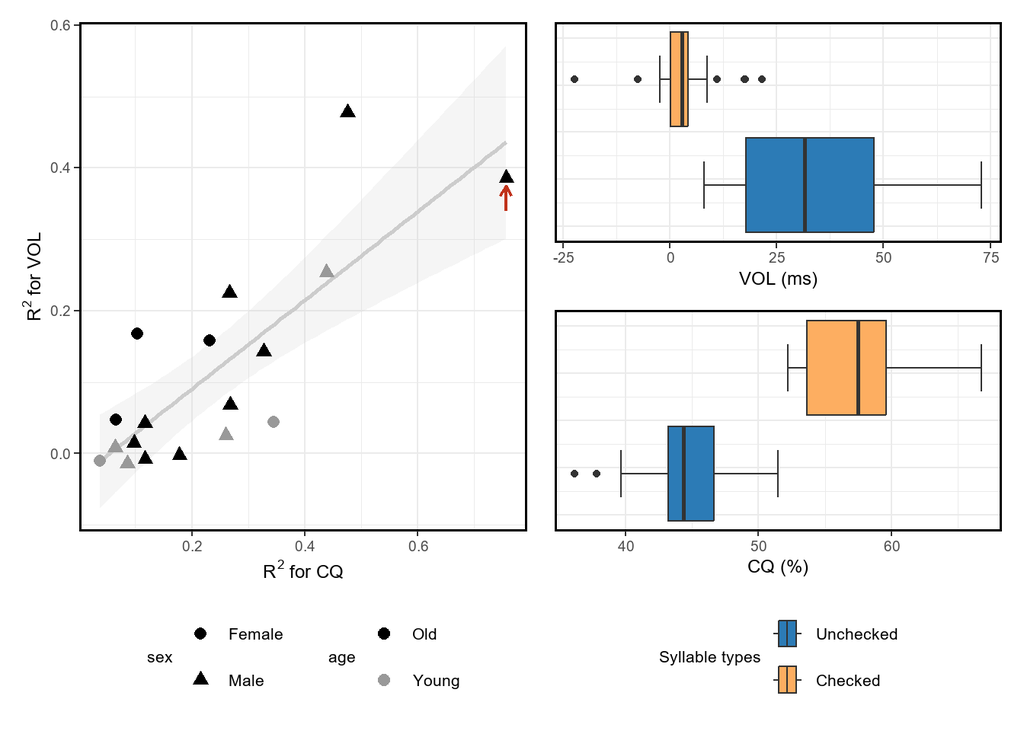

## Figure 3

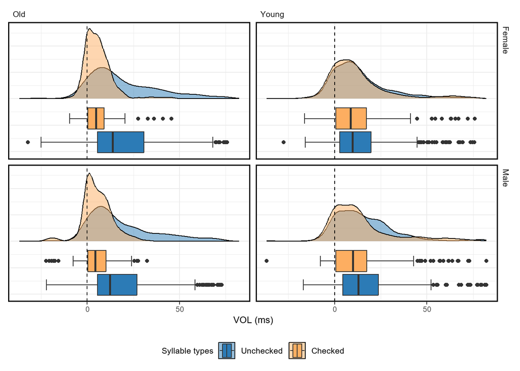

## Figure 4

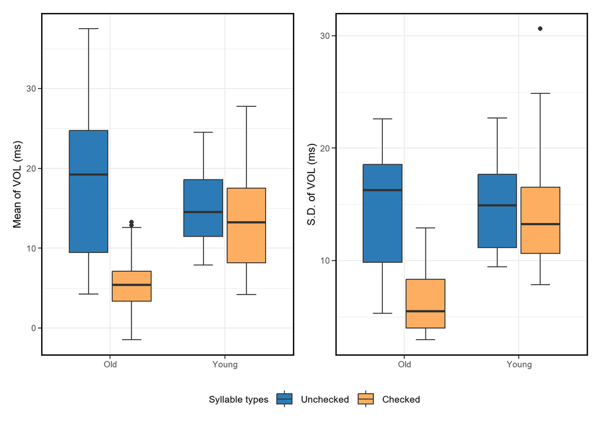